# Projekt1 SAD

Wiktoria Skowron

2022-10-22

**Cel pracy:** **Analiza wielkości produkcji i konsumpcji energii względem ilości wyemitowanego dwutlenku węgla w wybranych krajach światach.**

Dane dotyczą produkcji oraz konsumpcji, a także emitowanego dwutlenku węgla przez wybrane państwa świata w roku 2019. Ze zbioru danych po wstępnej analizie zostały wykluczone wartości odstające, czyli państwa takie jak Chiny, Stany Zjednoczone, Arabia Saudyjska czy Rosja. Wartości te znacznie zawyżały statystyki, co mogło spowodować przyjęcie błędnych założeń oraz wysunięcie mylnych wniosków.

|  | Energy_consumption | Energy_production | GDP | Population | Energy_intensity_per_capita | Energy_intensity_by_GDP | CO2_emission |
| --- | --- | --- | --- | --- | --- | --- | --- |
| Qatar | 2.046977 | 9.652517 | 247.0460 | 2828.950 | 723.581880 | 8.285813 | 105.34120 |
| Norway | 1.786945 | 8.857428 | 330.2825 | 5352.817 | 333.832643 | 5.410353 | 38.05578 |
| Kazakhstan | 3.352726 | 8.140284 | 464.7900 | 18544.500 | 180.793525 | 7.213420 | 269.71317 |
| Kuwait | 1.607041 | 7.123551 | 180.9910 | 4199.080 | 382.712522 | 8.879118 | 92.88917 |
| Algeria | 2.643503 | 6.429790 | 509.0660 | 43030.400 | 61.433374 | 5.192849 | 145.98797 |
| Nigeria | 1.701415 | 6.024305 | 1015.8890 | 201050.800 | 8.462611 | 1.674804 | 101.19393 |
| South Africa | 5.645541 | 5.913389 | 785.2230 | 58650.230 | 96.257782 | 7.189730 | 455.44860 |
| Mexico | 7.986493 | 5.909857 | 2384.1420 | 127745.800 | 62.518639 | 3.349840 | 456.14834 |
| United Kingdom | 8.095451 | 5.463957 | 2992.8170 | 66827.700 | 121.139160 | 2.704960 | 411.16785 |
| Colombia | 1.753107 | 5.073328 | 690.9870 | 50225.200 | 34.904935 | 2.537106 | 75.94597 |
| Malaysia | 3.960816 | 4.514936 | 908.7600 | 32005.270 | 123.755129 | 4.358484 | 247.42898 |
| Egypt | 4.021817 | 4.050868 | 1291.8100 | 100370.000 | 40.069908 | 3.113319 | 235.49450 |
| Turkmenistan | 1.963901 | 3.628148 | 110.9360 | 5940.010 | 330.622567 | 17.703012 | 97.30632 |
| Venezuela | 2.447475 | 3.551700 | 190.1472 | 28515.850 | 85.828574 | 12.871474 | 131.48505 |
| Argentina | 3.545507 | 3.493368 | 833.5010 | 44832.700 | 79.083060 | 4.253753 | 191.35866 |
| Oman | 1.348560 | 3.406913 | 141.2080 | 4618.000 | 292.022448 | 9.550165 | 75.86964 |
| Thailand | 5.342952 | 2.737214 | 1248.4170 | 69647.880 | 76.713779 | 4.279782 | 303.66717 |
| Vietnam | 3.509085 | 2.556372 | 915.5040 | 96425.900 | 36.391525 | 3.832955 | 241.80642 |
| Poland | 4.289824 | 2.361311 | 1217.9870 | 37963.620 | 112.998292 | 3.522061 | 319.67031 |
| Ukraine | 3.480644 | 2.334488 | 487.6980 | 42153.200 | 82.571298 | 7.136885 | 202.51334 |
| Uzbekistan | 1.902432 | 2.191340 | 257.4350 | 32966.100 | 57.708724 | 7.389949 | 99.38935 |
| Turkey | 6.609000 | 2.102168 | 2338.0150 | 83524.670 | 79.126323 | 2.826757 | 397.80054 |
| Pakistan | 3.434414 | 1.927664 | 1039.8800 | 216564.000 | 15.858657 | 3.302702 | 192.89699 |
| Sweden | 2.170195 | 1.554257 | 524.6200 | 10291.050 | 210.881826 | 4.136700 | 47.07986 |
| Spain | 5.789466 | 1.550597 | 1796.2930 | 47184.250 | 122.699114 | 3.223007 | 293.77947 |
| Italy | 6.723364 | 1.443412 | 2340.3710 | 59910.750 | 112.222996 | 2.872777 | 339.57706 |
| Netherlands | 3.817956 | 1.411145 | 934.9210 | 17360.550 | 219.921393 | 4.083721 | 216.83036 |
| Peru | 1.185506 | 1.167252 | 402.2800 | 32462.700 | 36.519023 | 2.946967 | 52.91850 |
| Bangladesh | 1.616633 | 1.109107 | 798.1130 | 163021.000 | 9.916715 | 2.025569 | 90.78163 |
| Romania | 1.388873 | 1.035851 | 522.9050 | 19360.950 | 71.735803 | 2.656072 | 73.68412 |

**Zmienne w zbiorze danych:**  
1. *Country*- nazwa danego kraju  
2. *Energy_consumption* - całkowita ilość zużytej energii w roku 2019  
*3. Energy_production -* całkowita ilość wyprodukowanej energii w roku 2019  
4. *GDP* - Produkt Krajowy Brutto [PKB]  
5. *Population* - liczebność mieszkańców danego kraju  
6. *Energyintensityper_capita* - energochłonność, względem liczby osób  
7. *Energyintensityby_GDP*- energochłonność, względem PKB  
8. *CO2_emission* - ilość wyemitowanego dwutlenku węgla

**Statystyki dla badanych zmiennych:**

Table continues below

|  | Energy_consumption | Energy_production | GDP |
| --- | --- | --- | --- |
| **nbr.val** | 30 | 30 | 30 |
| **nbr.null** | 0 | 0 | 0 |
| **nbr.na** | 0 | 0 | 0 |
| **min** | 1.186 | 1.036 | 110.9 |
| **max** | 8.095 | 9.653 | 2993 |
| **range** | 6.91 | 8.617 | 2882 |
| **sum** | 105.2 | 116.7 | 27902 |
| **median** | 3.394 | 3.45 | 791.7 |
| **mean** | 3.506 | 3.891 | 930.1 |
| **SE.mean** | 0.367 | 0.448 | 137.3 |
| **CI.mean.0.95** | 0.751 | 0.916 | 280.9 |
| **var** | 4.042 | 6.021 | 565851 |
| **std.dev** | 2.01 | 2.454 | 752.2 |
| **coef.var** | 0.573 | 0.631 | 0.809 |

Table continues below

|  | Population | Energy_intensity_per_capita |
| --- | --- | --- |
| **nbr.val** | 30 | 30 |
| **nbr.null** | 0 | 0 |
| **nbr.na** | 0 | 0 |
| **min** | 2829 | 8.463 |
| **max** | 216564 | 723.6 |
| **range** | 213735 | 715.1 |
| **sum** | 1723574 | 4202 |
| **median** | 42592 | 84.2 |
| **mean** | 57452 | 140.1 |
| **SE.mean** | 10223 | 27.28 |
| **CI.mean.0.95** | 20909 | 55.79 |
| **var** | 3.136e+09 | 22320 |
| **std.dev** | 55996 | 149.4 |
| **coef.var** | 0.975 | 1.067 |

|  | Energy_intensity_by_GDP | CO2_emission |
| --- | --- | --- |
| **nbr.val** | 30 | 30 |
| **nbr.null** | 0 | 0 |
| **nbr.na** | 0 | 0 |
| **min** | 1.675 | 38.06 |
| **max** | 17.7 | 456.1 |
| **range** | 16.03 | 418.1 |
| **sum** | 158.5 | 6003 |
| **median** | 4.11 | 192.1 |
| **mean** | 5.284 | 200.1 |
| **SE.mean** | 0.64 | 23.16 |
| **CI.mean.0.95** | 1.31 | 47.38 |
| **var** | 12.3 | 16099 |
| **std.dev** | 3.507 | 126.9 |
| **coef.var** | 0.664 | 0.634 |

Statystyki świadczą o znacznym zróżnicowaniu zmiennych, a także o wysokim stopniu zmienności każdej z nich.

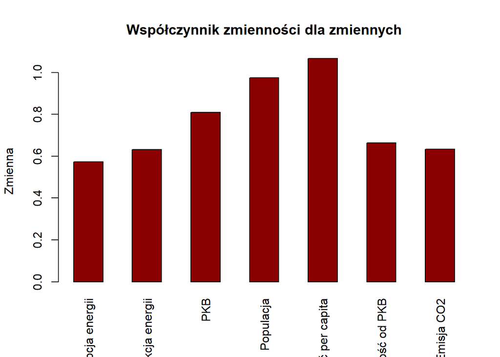

Poniżej przedstawiono macierz korelacji między badanymi zmiennymi. Większość par cechuje się umiarkowaną lub niską korelacją. Ciekawym spotrzeżeniem może być fakt, że ilość zużytej energii oraz emisji dwutlenku węgla są słabo skorelowane z ilością energii wytworzonej.

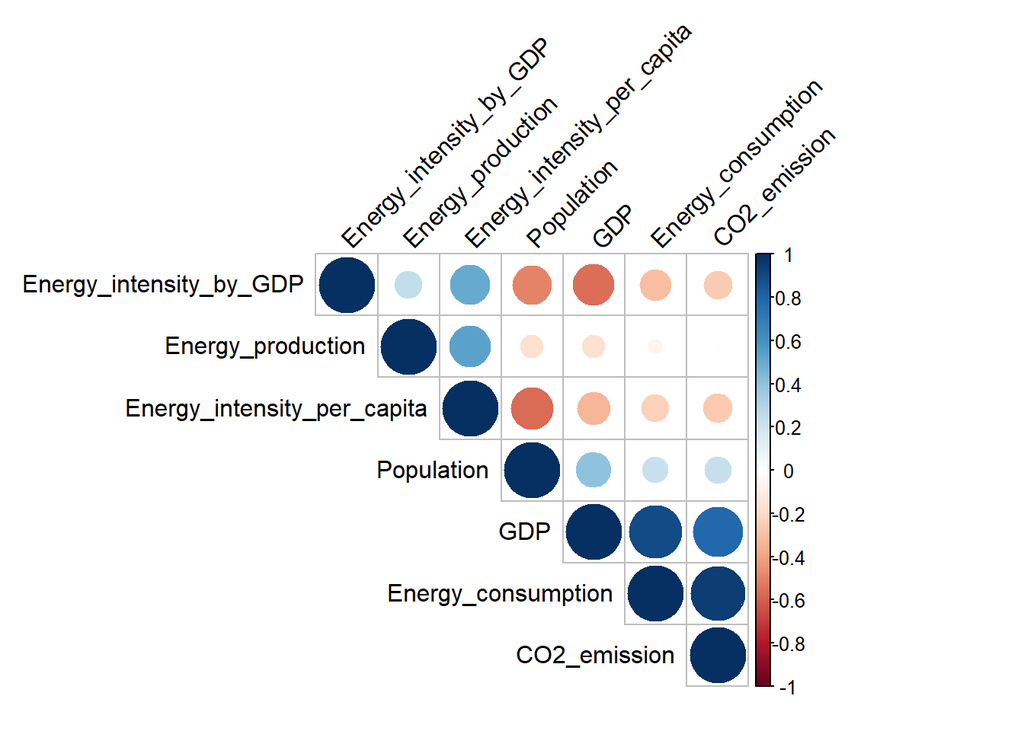

Na poniższych wykresach pudełkowych można zaobserwować, że średnia ilość energii wytworzonej oraz zużywanej są porównywalne. Jednak widać, że obserwacje dla zmiennej produkcji są znacznie bardziej zróżnicowane.

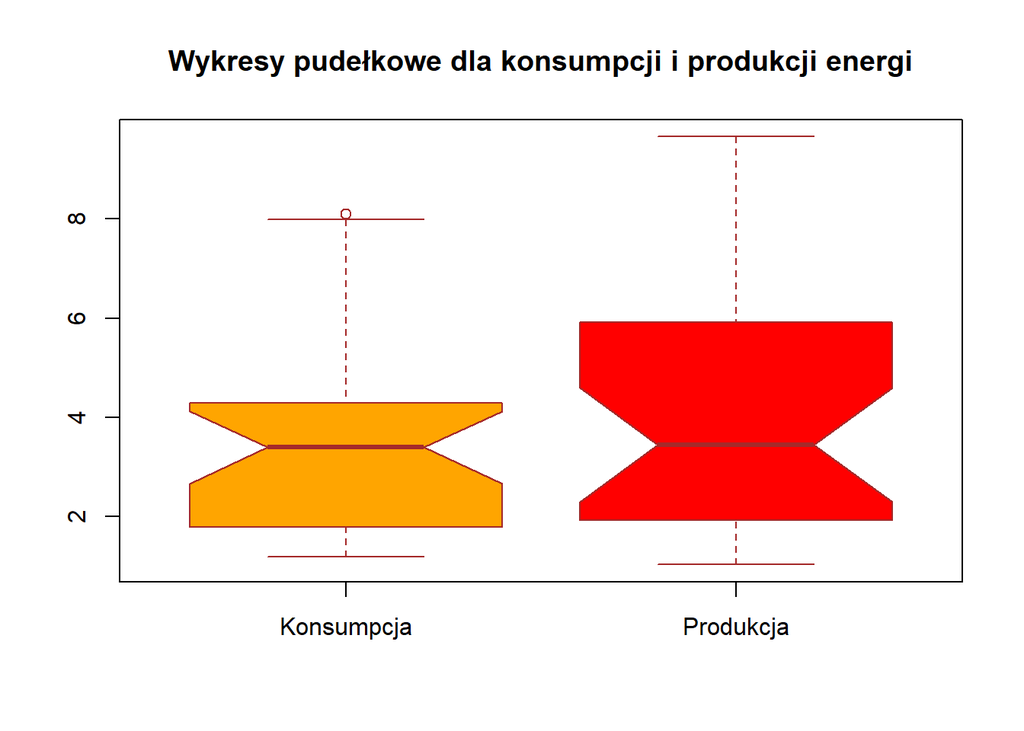

1. **Porządkowanie liniowe:**

Wśród badanych zmiennych wyodrębniono nominanty, które wymagają korekcji, destymulanty, których pożądana wartość powinna być możliwie najniższa oraz stymulanty, których wartości powinny być jak najwyższe.

Do pierwszej grupy zaliczono zmienne opisujące ilość energii wyprodukowanej i zużytej w danym kraju. Nie można jednoznacznie stwierdzić oczekiwań dotyczących ich wielkości. Wysoka konsumpcja energii może świadczyć zarówno o wysokim rozwoju gospodarczym kraju, ale również o nieefektywnym zarządzaniu zużyciem prądu. Niska produkcja energii mogłaby z jednej strony wskazywać na inwestycje w odnawialne źródła energii, a z drugiej klasyfikować państwo jako słabe pod względem rozwoju gospodarczego.

W badanym zbiorze danych stymulantami bez zwątpienia są wartości populacji oraz produktu krajowego brutto. W większości przypadków, czyli w krajach bez zwiększonego ryzyka przeludnienia, oczekuje się, że populacja będzie coraz większa. Podobnie z wartością wskaźnika PKB.

Jako destymulanty zaklasyfikowano zmienne powiązane z energochłonnością oraz emisją C02 z racji, że mają istotny wpływ na stan środowiska.

| zmienna | typ | wartosc |
| --- | --- | --- |
| Energy_consumption | nominanta | 3.5 |
| Energy_production | nominanta | 1.4 |
| GDP | stymulanta | max |
| Population | stymulanta | max |
| Energy_intensity_per_capita | destymulanta | min |
| Energy_intensity_by_GDP | destymulanta | min |
| CO2_emission | destymulanta | min |

Ustandaryzowany zbiór danych prezentuje się następująco:

Table continues below

|  | Energy_consumption_s | Energy_production_s | GDP_s |
| --- | --- | --- | --- |
| **Qatar** | -0.7356 | -0.398 | -0.908 |
| **Norway** | -0.6819 | -0.3753 | -0.7973 |
| **Kazakhstan** | -1.647 | -0.348 | -0.6185 |
| **Kuwait** | -0.6371 | -0.3049 | -0.9958 |
| **Algeria** | -0.9613 | -0.264 | -0.5597 |
| **Nigeria** | -0.6586 | -0.2367 | 0.1141 |
| **South Africa** | 0.5595 | -0.2299 | -0.1926 |
| **Mexico** | 0.3069 | -0.2299 | 1.933 |
| **United Kingdom** | 0.3015 | -0.1981 | 2.742 |
| **Colombia** | -0.6819 | -0.1594 | -0.3178 |
| **Malaysia** | 1.176 | -0.08899 | -0.02833 |
| **Egypt** | 1.176 | -0.02992 | 0.4809 |
| **Turkmenistan** | -0.7356 | 0.06552 | -1.089 |
| **Venezuela** | -0.8718 | 0.06552 | -0.9836 |
| **Argentina** | 1.772 | 0.09051 | -0.1284 |
| **Oman** | -0.578 | 0.1132 | -1.049 |
| **Thailand** | 0.6204 | 0.345 | 0.4232 |
| **Vietnam** | 1.772 | 0.3904 | -0.01936 |
| **Poland** | 0.9769 | 0.4927 | 0.3828 |
| **Ukraine** | 1.772 | 0.5518 | -0.5881 |
| **Uzbekistan** | -0.7088 | 0.6199 | -0.8942 |
| **Turkey** | 0.418 | 0.6926 | 1.872 |
| **Pakistan** | -1.647 | 0.8721 | 0.146 |
| **Sweden** | -0.7983 | 1.249 | -0.539 |
| **Spain** | 0.5237 | 1.249 | 1.152 |
| **Italy** | 0.4072 | 1.629 | 1.875 |
| **Netherlands** | 1.358 | 1.629 | 0.006452 |
| **Peru** | -0.5619 | -2.536 | -0.7016 |
| **Bangladesh** | -0.6371 | -2.391 | -0.1754 |
| **Romania** | -0.5977 | -2.266 | -0.5413 |

Table continues below

|  | Population_s | Energy_intensity_per_capita_s |
| --- | --- | --- |
| **Qatar** | -0.9755 | -3.906 |
| **Norway** | -0.9304 | -1.297 |
| **Kazakhstan** | -0.6948 | -0.2725 |
| **Kuwait** | -0.951 | -1.624 |
| **Algeria** | -0.2576 | 0.5264 |
| **Nigeria** | 2.564 | 0.881 |
| **South Africa** | 0.02139 | 0.2933 |
| **Mexico** | 1.255 | 0.5191 |
| **United Kingdom** | 0.1674 | 0.1268 |
| **Colombia** | -0.1291 | 0.704 |
| **Malaysia** | -0.4544 | 0.1092 |
| **Egypt** | 0.7664 | 0.6694 |
| **Turkmenistan** | -0.9199 | -1.275 |
| **Venezuela** | -0.5168 | 0.3631 |
| **Argentina** | -0.2254 | 0.4083 |
| **Oman** | -0.9435 | -1.017 |
| **Thailand** | 0.2178 | 0.4241 |
| **Vietnam** | 0.696 | 0.694 |
| **Poland** | -0.348 | 0.1812 |
| **Ukraine** | -0.2732 | 0.3849 |
| **Uzbekistan** | -0.4373 | 0.5513 |
| **Turkey** | 0.4656 | 0.408 |
| **Pakistan** | 2.841 | 0.8315 |
| **Sweden** | -0.8422 | -0.4739 |
| **Spain** | -0.1834 | 0.1163 |
| **Italy** | 0.0439 | 0.1864 |
| **Netherlands** | -0.716 | -0.5344 |
| **Peru** | -0.4463 | 0.6932 |
| **Bangladesh** | 1.885 | 0.8712 |
| **Romania** | -0.6803 | 0.4574 |

|  | Energy_intensity_by_GDP_s | CO2_emission_s |
| --- | --- | --- |
| **Qatar** | -0.8558 | 0.7469 |
| **Norway** | -0.03599 | 1.277 |
| **Kazakhstan** | -0.5501 | -0.5486 |
| **Kuwait** | -1.025 | 0.845 |
| **Algeria** | 0.02603 | 0.4265 |
| **Nigeria** | 1.029 | 0.7796 |
| **South Africa** | -0.5433 | -2.012 |
| **Mexico** | 0.5515 | -2.018 |
| **United Kingdom** | 0.7353 | -1.663 |
| **Colombia** | 0.7832 | 0.9786 |
| **Malaysia** | 0.2639 | -0.373 |
| **Egypt** | 0.6189 | -0.2789 |
| **Turkmenistan** | -3.541 | 0.8102 |
| **Venezuela** | -2.163 | 0.5408 |
| **Argentina** | 0.2938 | 0.06895 |
| **Oman** | -1.216 | 0.9792 |
| **Thailand** | 0.2863 | -0.8162 |
| **Vietnam** | 0.4137 | -0.3286 |
| **Poland** | 0.5024 | -0.9423 |
| **Ukraine** | -0.5282 | -0.01896 |
| **Uzbekistan** | -0.6004 | 0.7938 |
| **Turkey** | 0.7006 | -1.558 |
| **Pakistan** | 0.5649 | 0.05683 |
| **Sweden** | 0.3271 | 1.206 |
| **Spain** | 0.5876 | -0.7383 |
| **Italy** | 0.6875 | -1.099 |
| **Netherlands** | 0.3422 | -0.1318 |
| **Peru** | 0.6663 | 1.16 |
| **Bangladesh** | 0.929 | 0.8616 |
| **Romania** | 0.7493 | 0.9964 |

Zbiór ustandaryzowany w ten sposób można wykorzystać w porządkowaniu liniowym metodą Hellwiga oraz metodą standaryzowanych sum.

**1.1 Metoda Hellwiga:**

Na początku utworzono wzorzec, czyli obiekt posiadający wszystkie wartości pożądane. W tym celu dla każdej zmiennej wybrano najwyższą wartość, która po standaryzacji jest również najlepszą.

```r
wzorzec<-c(0)
for(i in 1:ncol(energy_stand)){
  wzorzec[i]<-max(energy_stand[,i])
}
```

| zmienna | wzorzec |
| --- | --- |
| Energy_consumption_s | 1.772 |
| Energy_production_s | 1.629 |
| GDP_s | 2.742 |
| Population_s | 2.841 |
| Energy_intensity_per_capita_s | 0.881 |
| Energy_intensity_by_GDP_s | 1.029 |
| CO2_emission_s | 1.277 |

Następnie obliczono kwadratową odległość każdej obserwacji od wzorca, a wyniki umieszczono w poniższej macierzy.

```r
odl_wzorzec<-energy_stand

for(i in 1:ncol(energy_stand)){
  for (j in 1:nrow(energy_stand)){
    odl_wzorzec[j,i]<-(energy_stand[j,i]-t(wzorzec[i,2]))^2
  }
}
```

Table continues below

|  | Energy_consumption_s | Energy_production_s | GDP_s |
| --- | --- | --- | --- |
| **Qatar** | 6.289 | 4.108 | 13.32 |
| **Norway** | 6.022 | 4.016 | 12.53 |
| **Kazakhstan** | 11.69 | 3.908 | 11.29 |
| **Kuwait** | 5.805 | 3.739 | 13.97 |
| **Algeria** | 7.472 | 3.582 | 10.9 |
| **Nigeria** | 5.909 | 3.48 | 6.907 |
| **South Africa** | 1.471 | 3.455 | 8.613 |
| **Mexico** | 2.147 | 3.455 | 0.6547 |
| **United Kingdom** | 2.163 | 3.337 | 0 |
| **Colombia** | 6.022 | 3.198 | 9.364 |
| **Malaysia** | 0.3558 | 2.951 | 7.676 |
| **Egypt** | 0.3558 | 2.751 | 5.113 |
| **Turkmenistan** | 6.289 | 2.444 | 14.68 |
| **Venezuela** | 6.99 | 2.444 | 13.88 |
| **Argentina** | 0 | 2.366 | 8.24 |
| **Oman** | 5.523 | 2.297 | 14.37 |
| **Thailand** | 1.327 | 1.648 | 5.378 |
| **Vietnam** | 0 | 1.534 | 7.626 |
| **Poland** | 0.6326 | 1.291 | 5.567 |
| **Ukraine** | 0 | 1.16 | 11.09 |
| **Uzbekistan** | 6.155 | 1.018 | 13.22 |
| **Turkey** | 1.834 | 0.8764 | 0.7577 |
| **Pakistan** | 11.69 | 0.5725 | 6.74 |
| **Sweden** | 6.608 | 0.144 | 10.77 |
| **Spain** | 1.559 | 0.144 | 2.53 |
| **Italy** | 1.863 | 0 | 0.7523 |
| **Netherlands** | 0.1712 | 0 | 7.484 |
| **Peru** | 5.448 | 17.35 | 11.86 |
| **Bangladesh** | 5.805 | 16.16 | 8.512 |
| **Romania** | 5.616 | 15.17 | 10.78 |

Table continues below

|  | Population_s | Energy_intensity_per_capita_s |
| --- | --- | --- |
| **Qatar** | 14.57 | 22.91 |
| **Norway** | 14.23 | 4.743 |
| **Kazakhstan** | 12.51 | 1.331 |
| **Kuwait** | 14.38 | 6.275 |
| **Algeria** | 9.604 | 0.1257 |
| **Nigeria** | 0.07675 | 0 |
| **South Africa** | 7.953 | 0.3453 |
| **Mexico** | 2.516 | 0.1309 |
| **United Kingdom** | 7.151 | 0.5688 |
| **Colombia** | 8.824 | 0.03133 |
| **Malaysia** | 10.86 | 0.5955 |
| **Egypt** | 4.306 | 0.04476 |
| **Turkmenistan** | 14.15 | 4.65 |
| **Venezuela** | 11.28 | 0.2682 |
| **Argentina** | 9.406 | 0.2234 |
| **Oman** | 14.33 | 3.602 |
| **Thailand** | 6.884 | 0.2087 |
| **Vietnam** | 4.603 | 0.03495 |
| **Poland** | 10.17 | 0.4896 |
| **Ukraine** | 9.701 | 0.2461 |
| **Uzbekistan** | 10.75 | 0.1087 |
| **Turkey** | 5.645 | 0.2237 |
| **Pakistan** | 0 | 0.002451 |
| **Sweden** | 13.57 | 1.836 |
| **Spain** | 9.15 | 0.5847 |
| **Italy** | 7.826 | 0.4824 |
| **Netherlands** | 12.66 | 2.003 |
| **Peru** | 10.81 | 0.03527 |
| **Bangladesh** | 0.9143 | 9.473e-05 |
| **Romania** | 12.4 | 0.1794 |

|  | Energy_intensity_by_GDP_s | CO2_emission_s |
| --- | --- | --- |
| **Qatar** | 3.553 | 0.2812 |
| **Norway** | 1.134 | 0 |
| **Kazakhstan** | 2.494 | 3.334 |
| **Kuwait** | 4.219 | 0.1868 |
| **Algeria** | 1.006 | 0.7236 |
| **Nigeria** | 0 | 0.2476 |
| **South Africa** | 2.472 | 10.82 |
| **Mexico** | 0.2281 | 10.86 |
| **United Kingdom** | 0.08626 | 8.647 |
| **Colombia** | 0.06044 | 0.08918 |
| **Malaysia** | 0.5854 | 2.723 |
| **Egypt** | 0.1682 | 2.421 |
| **Turkmenistan** | 20.88 | 0.2181 |
| **Venezuela** | 10.19 | 0.5422 |
| **Argentina** | 0.5406 | 1.46 |
| **Oman** | 5.041 | 0.08882 |
| **Thailand** | 0.5516 | 4.382 |
| **Vietnam** | 0.3786 | 2.579 |
| **Poland** | 0.2774 | 4.926 |
| **Ukraine** | 2.425 | 1.68 |
| **Uzbekistan** | 2.655 | 0.2337 |
| **Turkey** | 0.1079 | 8.039 |
| **Pakistan** | 0.2154 | 1.489 |
| **Sweden** | 0.4927 | 0.005058 |
| **Spain** | 0.1948 | 4.062 |
| **Italy** | 0.1167 | 5.647 |
| **Netherlands** | 0.4717 | 1.985 |
| **Peru** | 0.1316 | 0.01372 |
| **Bangladesh** | 0.01 | 0.1727 |
| **Romania** | 0.07827 | 0.07885 |

```r
odl_wzorzec.sum <-apply(odl_wzorzec,1,sum)

odl_wzorzec.sum.sqrt<-sqrt(odl_wzorzec.sum)
```

|  | odl_wzorzec.sum | odl_wzorzec.sum.sqrt |
| --- | --- | --- |
| **Qatar** | 65.04 | 8.064 |
| **Norway** | 42.67 | 6.532 |
| **Kazakhstan** | 46.56 | 6.823 |
| **Kuwait** | 48.58 | 6.97 |
| **Algeria** | 33.42 | 5.781 |
| **Nigeria** | 16.62 | 4.077 |
| **South Africa** | 35.13 | 5.927 |
| **Mexico** | 19.99 | 4.471 |
| **United Kingdom** | 21.95 | 4.685 |
| **Colombia** | 27.59 | 5.253 |
| **Malaysia** | 25.75 | 5.074 |
| **Egypt** | 15.16 | 3.894 |
| **Turkmenistan** | 63.31 | 7.957 |
| **Venezuela** | 45.59 | 6.752 |
| **Argentina** | 22.24 | 4.715 |
| **Oman** | 45.25 | 6.727 |
| **Thailand** | 20.38 | 4.514 |
| **Vietnam** | 16.75 | 4.093 |
| **Poland** | 23.36 | 4.833 |
| **Ukraine** | 26.3 | 5.129 |
| **Uzbekistan** | 34.14 | 5.843 |
| **Turkey** | 17.48 | 4.181 |
| **Pakistan** | 20.71 | 4.551 |
| **Sweden** | 33.42 | 5.781 |
| **Spain** | 18.22 | 4.269 |
| **Italy** | 16.69 | 4.085 |
| **Netherlands** | 24.77 | 4.977 |
| **Peru** | 45.64 | 6.756 |
| **Bangladesh** | 31.57 | 5.619 |
| **Romania** | 44.3 | 6.656 |

Obliczenie odległości możliwie dalekiej:

```r
m<-mean(odl_wzorzec$odl_wzorzec.sum.sqrt)
sd<-sd(odl_wzorzec$odl_wzorzec.sum.sqrt)
d0=m+2*sd
d0
```

```
## [1] 7.883545
```

Aby porównać który kraj ma pożądane parametry związane z energią , czyli jest najbardziej zbliżony do określonego wcześniej wzorca dla każdego państwa obliczono ocenę dopasowania do wzorca.

```r
ranking<-c(30)

for(i in 1:nrow(odl_wzorzec)){
  ranking[i]<-(1-(odl_wzorzec[i,2]/d0))
}
```

Najlepszy obiekt przyjmuje wartość największą, a najgorszy najmniejszą. Dlatego by w łatwy sposób ocenić obiekty ranking został posortowany.

|  | score |
| --- | --- |
| **Egypt** | 0.5061 |
| **Nigeria** | 0.4829 |
| **Italy** | 0.4818 |
| **Vietnam** | 0.4808 |
| **Turkey** | 0.4696 |
| **Spain** | 0.4585 |
| **Mexico** | 0.4329 |
| **Thailand** | 0.4274 |
| **Pakistan** | 0.4227 |
| **United Kingdom** | 0.4057 |
| **Argentina** | 0.4019 |
| **Poland** | 0.387 |
| **Netherlands** | 0.3687 |
| **Malaysia** | 0.3563 |
| **Ukraine** | 0.3494 |
| **Colombia** | 0.3337 |
| **Bangladesh** | 0.2873 |
| **Algeria** | 0.2667 |
| **Sweden** | 0.2667 |
| **Uzbekistan** | 0.2588 |
| **South Africa** | 0.2482 |
| **Norway** | 0.1714 |
| **Romania** | 0.1557 |
| **Oman** | 0.1467 |
| **Venezuela** | 0.1435 |
| **Peru** | 0.143 |
| **Kazakhstan** | 0.1345 |
| **Kuwait** | 0.1159 |
| **Turkmenistan** | -0.009282 |
| **Qatar** | -0.02295 |

**Wnioski:** Z zaprezentowanego porządkowania linowego metodą Hellwiga można wyciągnąć bardzo ciekawe i dosyć niespodziewane wnioski.

Według otrzymanego rankingu najlepszym energetycznie krajem jest Egipt. W czołówce są również takie państwa jak Włochy, Nigeria oraz Vietnam. Tak wysoka ocena tych obiektów może być zaburzona przez wskaźnik energochłonności per capita. Kraje te charakteryzują się dużym zaludnieniem, przez co mógł być istotnie zaniżony.

Jako najgorsze z analizowanych krajów pod względem energetycznym ranking wskazuje Katar, Turkmenistan oraz Kuwejt.

**1.2 Metoda Standaryzowanych sum:**

Na początku zbudowano syntetyczną miarę po przez zsumowanie oszacowań uzyskanych w ramach obiektów.

```r
s=c(7)

for(i in 1:ncol(energy_stand)){
  s[i]=sum(energy_stand[,i])/mean(energy_stand[,i])
}
```

| zmienna | s |
| --- | --- |
| Energy_consumption_s | 29.2 |
| Energy_production_s | 29.85 |
| GDP_s | 29.99 |
| Population_s | 29.98 |
| Energy_intensity_per_capita_s | 28.55 |
| Energy_intensity_by_GDP_s | 29.99 |
| CO2_emission_s | 30 |

```r
rang.mean <-apply(energy_stand,1,mean)

ranking<-(rang.mean - min(rang.mean)) / max(rang.mean - min(rang.mean))
```

|  | rang.mean | score |
| --- | --- | --- |
| **Nigeria** | 0.639 | 1 |
| **Italy** | 0.5328 | 0.9354 |
| **Pakistan** | 0.5236 | 0.9298 |
| **Vietnam** | 0.5169 | 0.9257 |
| **Egypt** | 0.4861 | 0.907 |
| **Turkey** | 0.4283 | 0.8718 |
| **Spain** | 0.3867 | 0.8465 |
| **Mexico** | 0.3311 | 0.8127 |
| **Argentina** | 0.3257 | 0.8094 |
| **United Kingdom** | 0.316 | 0.8035 |
| **Netherlands** | 0.2791 | 0.781 |
| **Thailand** | 0.2144 | 0.7417 |
| **Bangladesh** | 0.192 | 0.728 |
| **Ukraine** | 0.1858 | 0.7242 |
| **Poland** | 0.1779 | 0.7195 |
| **Colombia** | 0.1682 | 0.7136 |
| **Malaysia** | 0.0863 | 0.6637 |
| **Sweden** | 0.01844 | 0.6224 |
| **Uzbekistan** | -0.09651 | 0.5525 |
| **Algeria** | -0.1519 | 0.5188 |
| **Peru** | -0.2466 | 0.4612 |
| **Romania** | -0.2688 | 0.4476 |
| **South Africa** | -0.3006 | 0.4283 |
| **Norway** | -0.4058 | 0.3643 |
| **Venezuela** | -0.5094 | 0.3013 |
| **Oman** | -0.5302 | 0.2886 |
| **Kazakhstan** | -0.6686 | 0.2044 |
| **Kuwait** | -0.6704 | 0.2033 |
| **Turkmenistan** | -0.955 | 0.03015 |
| **Qatar** | -1.005 | 0 |

**Wnioski:** Z zaprezentowanego porządkowania linowego metodą standaryzowanych sum można wyciągnąć bardzo podobne wnioski do tych z metody Hellwiga.

Według otrzymanego rankingu najlepszym energetycznie krajem jest Nigiera. Czołówka najlepszych krajów jest podobna do tej uzyskanej za pomocą porządkowania liniowego metodą Hellwiga.

Jako najgorsze z analizowanych krajów pod względem energetycznym ranking wskazuje (tak samo jak w metodzie Hellwiga) Katar, Turkmenistan oraz Kuwejt.

2. **Analiza skupień**

Przed wykonaniem analizy skupień należy upewnić się, że dane są kompletne (nie ma pustych obserwacji) oraz dokonać standaryzacji zmiennych.

Na podstawie przedstawionej macierzy ciężko jednoznacznie stwierdzić, czy więcej jest par obiektów do siebie podobnych czy różnych.

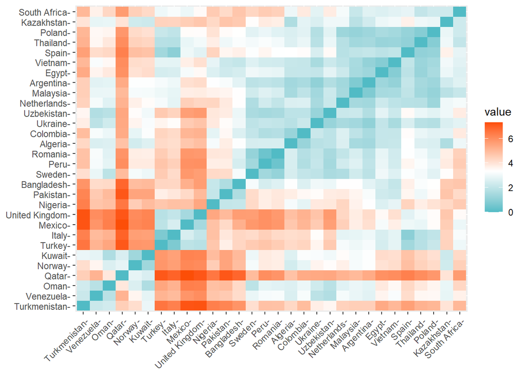

**2.1 Grupowanie podziałowe - metoda k-średnich**

W metodzie k-średnich należy zdefiniować liczbę skupień/klastrów tak żeby zminimalizować zmienność w danej grupie obiektów.

Graficzną różnicę między podziałem obiektów na różne ilości klastrów można zaobserwować na poniższych wykresach.

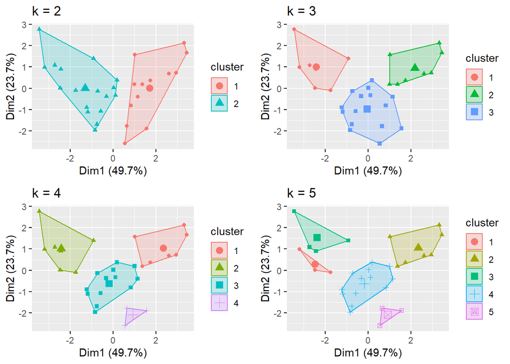

Warto zauważyć, że wraz z większeniem liczby grup, na które dzielimy obiekty są one do siebie coraz bardziej podobne w grupach. Celem kolejnych analiz jest wyznaczenie optymalnej ilości klastrów tak by połączyć ze sobą obiekty o podobnych cechach, ale również nie rozdzielać zbędnie obserwacji o nieistonych różnicach.

**Metoda Łokciowa** (*elbow method*)

Według tej metody optymalną liczbą klastrów jest 3.

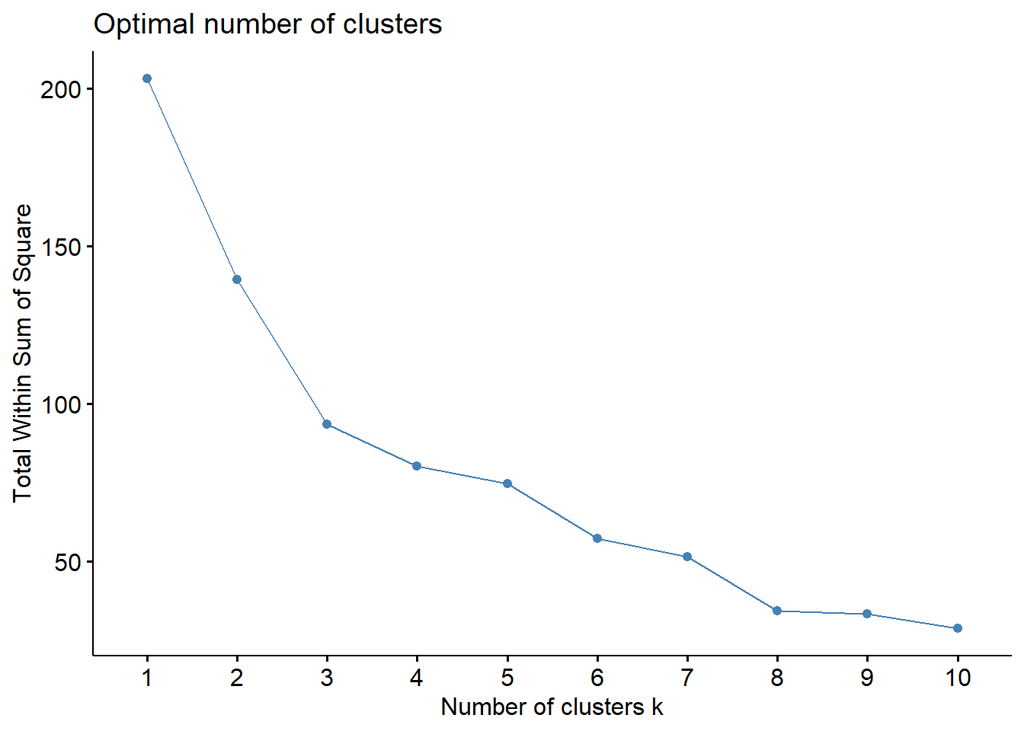

```r
set.seed(100)
fviz_nbclust(energy_stand, kmeans, method = "wss")
```

**Metoda sylwetki**

Według tej metody optymalną liczbą klastrów jest 9.

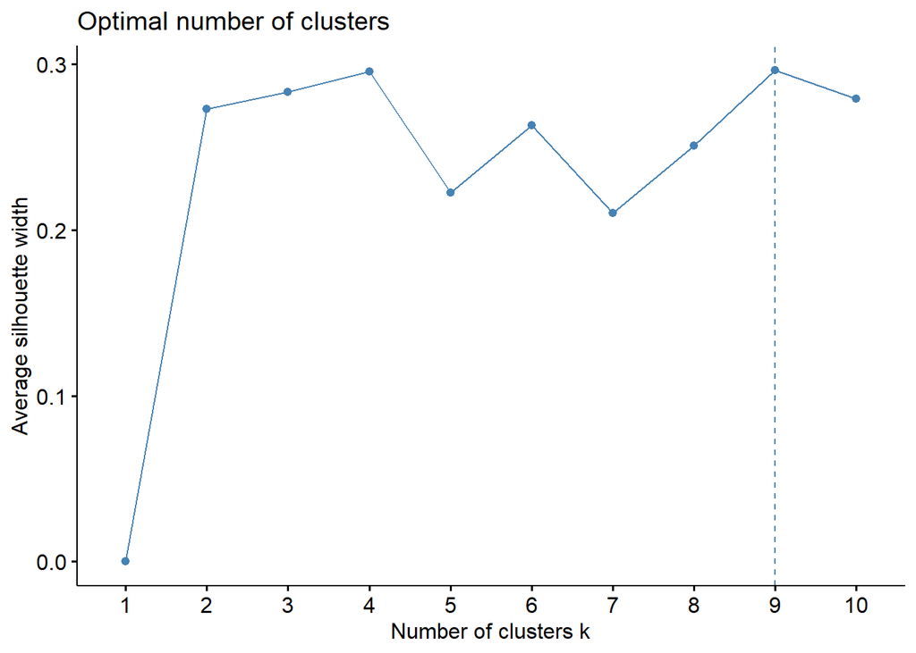

```r
set.seed(100)
fviz_nbclust(energy_stand, kmeans, method = "silhouette")
```

Wyznaczono optymalną liczbę klas jako średnią z metody łokciowej i metody sylwetki. W dalszych rozważaniach obiekty zostaną podzielone na 6 grup.

Podzial badanych państw na klastry prezentuje się następująco:

Klaster 1: Algeria, Kolumbia, Uzbekistan, Szwecja, Peru, Rumunia

Klaster 2: Turkmenistan, Wenezuela, Oman

Klaster 3: Nigeria, Pakistan, Bangladesz

Klaster 4: Katar, Norwegia, Kazachstan, Kuwejt

Klaster 5: RPA, Malezja, Egipt, Argentyna, Tajlandia, Wietnam, Polska, Ukraina, Hiszpania, Holandia

Klaster 6: Meksyk, Wielka Brytania, Turcja, Włochy

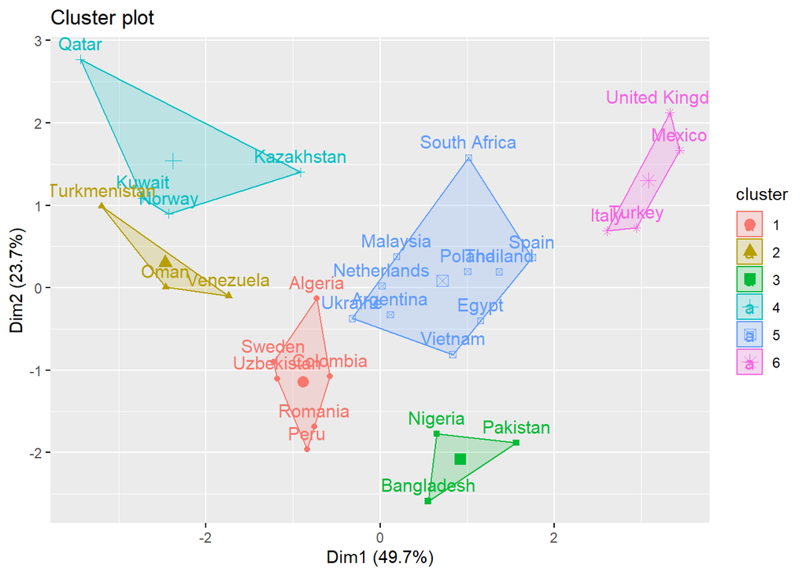

```r
fviz_cluster(final, data = energy_stand)
```

Podział w większości przypadków wydaje się sensowny i przewidalny, jednak niektóre połączenia mogą zastanawiać. Ciekawym przypadkiem wynikającym powyższego klastrowania jest zaklasyfikowanie Polski, Ukrainy, Hiszpani i Holandii do grupy z państwami afrykańskimi i azjatyckimi. Zastanawiający może być także fakt, że bardzo rozwinięta Szwecja jest w jednej grupie z państwami postrzeganymi jako wolnorozwijające się.

Aby zbadać podział na klastry przedstawiono średnie wartości zmiennych w każdej z grup.

```r
energy<-energy %>%
  mutate(Cluster = final$cluster) %>%
  group_by(Cluster) %>%
  summarise_all("mean")
pander::pander(energy,missing='')
```

Table continues below

| Cluster | Energy_consumption | Energy_production | GDP | Population |
| --- | --- | --- | --- | --- |
| 1 | 1.841 | 2.909 | 484.5 | 31389 |
| 2 | 1.92 | 3.529 | 147.4 | 13025 |
| 3 | 2.251 | 3.02 | 951.3 | 193545 |
| 4 | 2.198 | 8.443 | 305.8 | 7731 |
| 5 | 4.34 | 3.092 | 1042 | 54659 |
| 6 | 7.354 | 3.73 | 2514 | 84502 |

| Energy_intensity_per_capita | Energy_intensity_by_GDP | CO2_emission |
| --- | --- | --- |
| 78.86 | 4.143 | 82.5 |
| 236.2 | 13.37 | 101.6 |
| 11.41 | 2.334 | 128.3 |
| 405.2 | 7.447 | 126.5 |
| 99.05 | 4.499 | 270.8 |
| 93.75 | 2.939 | 401.2 |

**Wnioski:** Podział na klastry uzyskany za pomocą metody k-średnich w przypadku badanego zbioru danych dla większości obserwacji wydaje się być dobry i logiczny. Wcześniej opisane wyjątki dotyczące wątpliwych klasyfikacji prawdopodobnie są spowodowane główną wadą użytej metody, czyli faktem, że wymaga ona wstępnego określenia liczby klastrów.

Alternatywną metodą dla metody k-średnich może być metoda klasteryzacji hierarchicznej, ponieważ nie oczekuje podania konkretnej liczby klastrów.

**2.2 Grupowanie hierarchiczne**

Aby dokonać grupowania hierarchicznego należy najpierw wybrać odpowiednią metodę. Przy wyborze kierowano się *Agglomerative coefficient,* czyli współczynnikiem aglomeracyjnym. Wartość współczynnika uzyskano przy zastosowaniu funkcji *agnes*, która pozwala skonstruować hierarchię skupień, w której liczba skupień przyjmuje wartości od jednego do liczby obserwacji.

```r
m <- c( "average", "single", "complete", "ward")
names(m) <- m

ac <- function(x) {
  agnes(energy_stand, method = x)$ac
}

map_dbl(m, ac)
```

```
##   average    single  complete      ward
## 0.7341512 0.4953201 0.8142913 0.8759676
```

Współczynnik aglomeracyjny osiąga największą wartość dla metody Warda, dlatego ta metoda zostanie zastosowana w dalszych analizach.

Przed wyborem optymalnej liczby grup należy przeprowadzić analizę dendrogramu, analizę wykresu odległości wiązania względem etapów wiązania oraz analizę indeksów ocen jakości klasyfikacji.

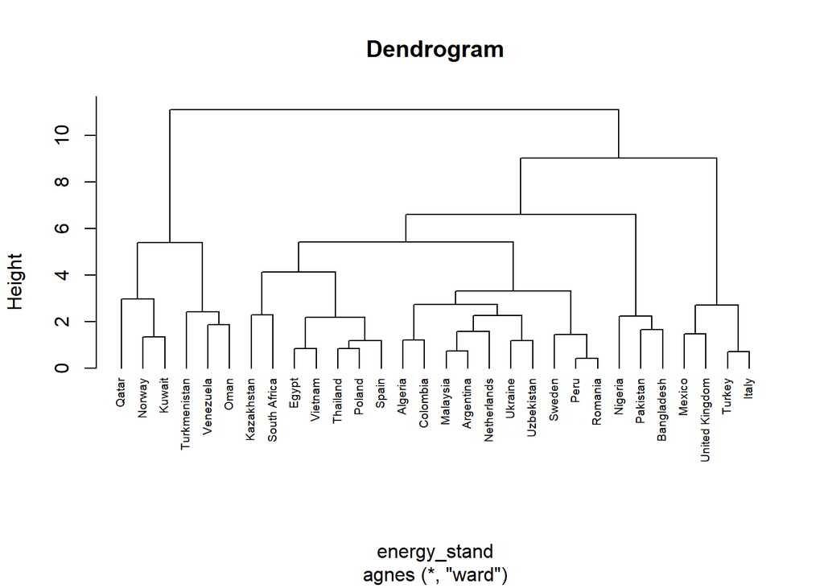

```r
#analiza dendrogramu
hc <- agnes(energy_stand, method = "ward")
pltree(hc, cex = 0.6, hang = -1, main = "Dendrogram")
```

Indeksami ocen jakości klasyfikacji są:

- index Calińskiego i Harabasza - *Index G1*
- index Bakera i Huberta - *Index G2*
- index Huberta i Levine’a - *Index G3*
- index Silhouette - *Index S*

Dla indeksów G1, G2 oraz S wartość indeksu jest wprostproporcjonalna do wysokości jakości klasyfikacji. Dla indeksu G3 są to wartości odwrotnie proporcjonalne.

```r
min_k=2
max_k=9

resG1 <- resG2 <- resG3 <-resS <- array(0,c(max_k-min_k+1,2))
resG1[,1] <- resG2[,1] <- resG3[,1]<- resS[,1] <- min_k:max_k

#index G1
clusters <- NULL
for (nc in min_k:max_k){
  cl <- pam(distance, nc, diss=TRUE)
  resG1[nc-min_k+1,2] <- G1 <- index.G1(energy_stand,cl$cluster,centrotypes="centroids")
  clusters <- rbind(clusters, cl$cluster)
}

#index G2
clusters <- NULL
for (nc in min_k:max_k){
  cl <- pam(distance, nc, diss=TRUE)
  resG2[nc-min_k+1,2] <- G2 <- index.G2(distance,cl$cluster)
  clusters <- rbind(clusters,cl$cluster)
  }

#index G3
clusters <- NULL
for (nc in min_k:max_k){
  hc <- hclust(distance, method="complete")
  cl <- cutree(hc, k=nc)
  resG3[nc-min_k+1,2] <- G3 <- index.G3(distance,cl)
  clusters <- rbind(clusters,cl)
}

#index S
clusters <- NULL
for (nc in min_k:max_k)
{
cl <- pam(distance, nc, diss=TRUE)
resS[nc-min_k+1, 2] <- S <- index.S(distance,cl$cluster)
clusters <- rbind(clusters, cl$cluster)
}
```

Graficzną ilustrację wartości analizowanych indeksów dla podziałów na klastry od 2 do 9 przedstawiono poniżej.

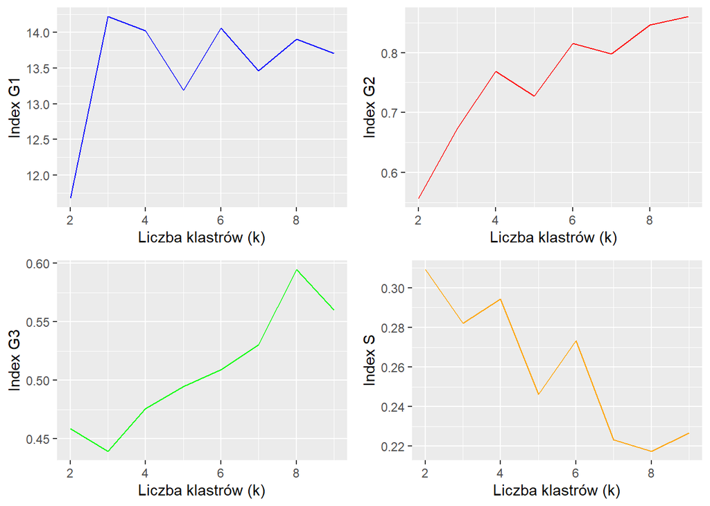

Optymalne ilości klastrów wyznaczone na podstawie badanych indeksów częściowo różnią się od siebie. Po dokładnej analizie wykresów wartości indeksów, a także dendrogramu za liczbę klastrów używaną w dalszych analizach przyjęto 4. Decyzję podjęto na podstawie zauważeń, że dla liczby k=4 indeksy nadal przyjmują niemal pożądane wartości, co pokrywa się także ze średnią arytmetyczną ze wszystkich optymalnych k.

```
## [1] "max G1 for 3 clusters = 14.2163213967598"
```

```
## [1] "max G2 for 9 clusters = 0.860050890585242"
```

```
## [1] "min G3 for 3 clusters = 0.439212940451649"
```

```
## [1] "max S for 2 clusters = 0.309166940306451"
```

```
## [1] "optimal number of clusters: 4"
```

```r
hc <- hclust(distance, method = "ward.D2")

# Cut tree into 4 groups
sub_grp <- cutree(hc, k = 4)

# Number of members in each cluster
table(sub_grp)
```

```
## sub_grp
##  1  2  3  4
##  6 17  3  4
```

```r
energy<-data.frame(row.names=row.names(energy_stand),cluster = sub_grp)
pander::pander(t(energy),missing='')
```

Table continues below

|  | Qatar | Norway | Kazakhstan | Kuwait | Algeria | Nigeria |
| --- | --- | --- | --- | --- | --- | --- |
| **cluster** | 1 | 1 | 2 | 1 | 2 | 3 |

Table continues below

|  | South Africa | Mexico | United Kingdom | Colombia | Malaysia |
| --- | --- | --- | --- | --- | --- |
| **cluster** | 2 | 4 | 4 | 2 | 2 |

Table continues below

|  | Egypt | Turkmenistan | Venezuela | Argentina | Oman | Thailand |
| --- | --- | --- | --- | --- | --- | --- |
| **cluster** | 2 | 1 | 1 | 2 | 1 | 2 |

Table continues below

|  | Vietnam | Poland | Ukraine | Uzbekistan | Turkey | Pakistan |
| --- | --- | --- | --- | --- | --- | --- |
| **cluster** | 2 | 2 | 2 | 2 | 4 | 3 |

|  | Sweden | Spain | Italy | Netherlands | Peru | Bangladesh | Romania |
| --- | --- | --- | --- | --- | --- | --- | --- |
| **cluster** | 2 | 2 | 4 | 2 | 2 | 3 | 2 |

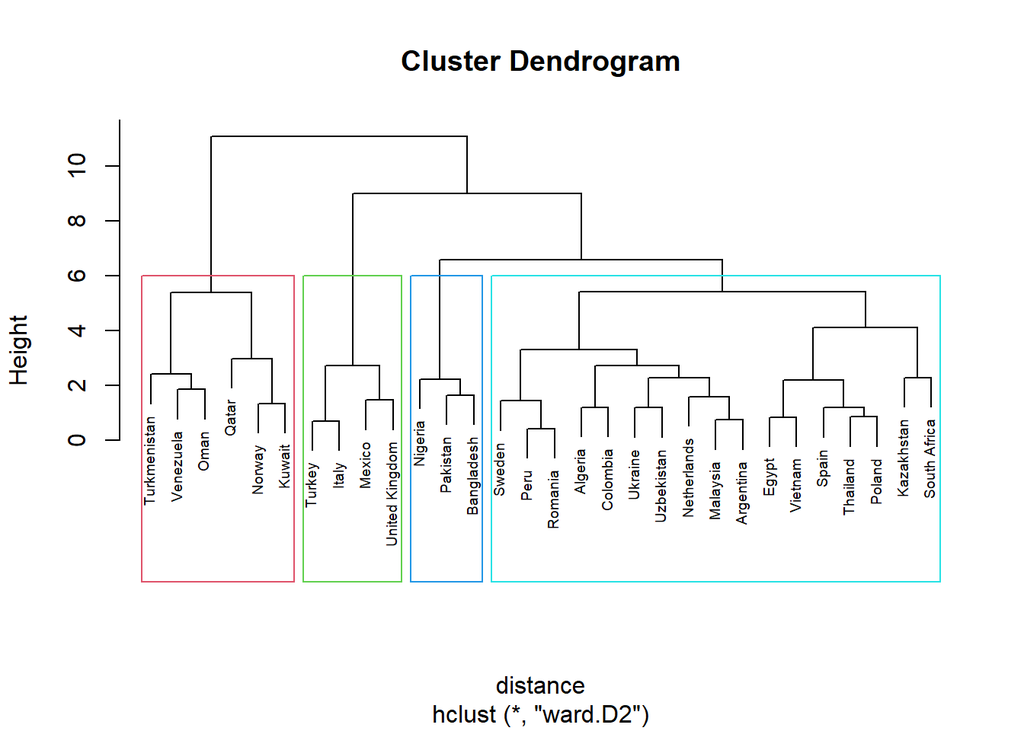

```r
plot(hc, cex = 0.6)
rect.hclust(hc, k = 4, border = 2:5)
```

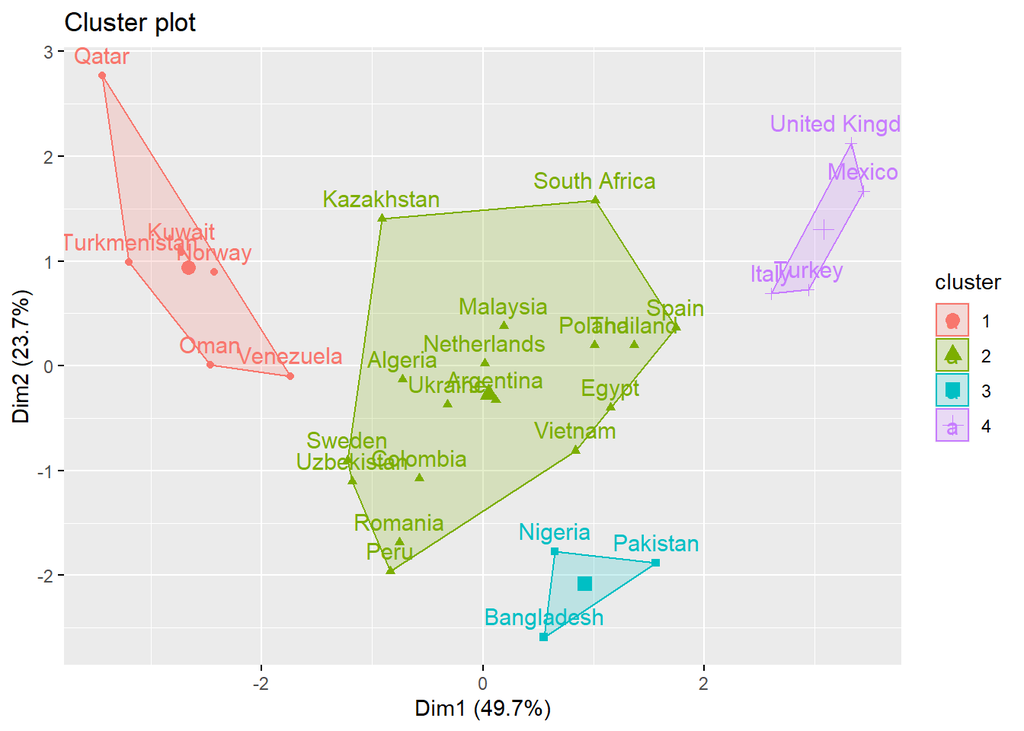

```r
fviz_cluster(list(data = energy_stand, cluster = sub_grp))
```

3. **Skalowanie wielowymiarowe**

```r
# Classical MDS
# N rows (objects) x p columns (variables)
# each row identified by a unique row name

d <- dist(energy_stand) # euclidean distances between the rows
fit <- cmdscale(d,eig=TRUE, k=2) # k is the number of dim
fit # view results
```

```
## $points
##                       [,1]        [,2]
## Qatar          -3.44297559 -2.77194423
## Norway         -2.42624988 -0.89668060
## Kazakhstan     -0.91505965 -1.40144910
## Kuwait         -2.72491356 -1.08683249
## Algeria        -0.72486364  0.13023551
## Nigeria         0.65140678  1.77276554
## South Africa    1.01618193 -1.57762090
## Mexico          3.44190580 -1.66709119
## United Kingdom  3.32557943 -2.12483813
## Colombia       -0.57437052  1.07603684
## Malaysia        0.18949120 -0.37865389
## Egypt           1.15147617  0.39878430
## Turkmenistan   -3.19655811 -0.98766177
## Venezuela      -1.73944249  0.09688065
## Argentina       0.11634993  0.32494682
## Oman           -2.46093492 -0.00548252
## Thailand        1.36588463 -0.19475552
## Vietnam         0.83323908  0.80929933
## Poland          1.00534858 -0.19676132
## Ukraine        -0.31885331  0.37144963
## Uzbekistan     -1.18168796  1.10100372
## Turkey          2.94132821 -0.72665923
## Pakistan        1.56333418  1.88052364
## Sweden         -1.22563281  0.89760633
## Spain           1.74742756 -0.36690470
## Italy           2.60393921 -0.68780402
## Netherlands     0.01872413 -0.02479601
## Peru           -0.83449523  1.96312605
## Bangladesh      0.55067341  2.58895601
## Romania        -0.75625254  1.68432128
##
## $eig
##  [1]  1.009691e+02  4.808009e+01  2.470544e+01  1.582662e+01  9.477343e+00
##  [6]  3.488489e+00  4.528934e-01  1.125819e-14  9.330489e-15  4.187356e-15
## [11]  1.666410e-15  1.579822e-15  1.221124e-15  9.148010e-16  7.853697e-16
## [16]  4.493789e-16  3.726914e-16  3.375306e-16  3.289053e-16  1.880311e-16
## [21] -1.072255e-15 -1.176570e-15 -1.439585e-15 -1.696093e-15 -2.246060e-15
## [26] -2.247788e-15 -5.935678e-15 -6.186906e-15 -7.135634e-15 -1.459725e-14
##
## $x
## NULL
##
## $ac
## [1] 0
##
## $GOF
## [1] 0.7342326 0.7342326
```

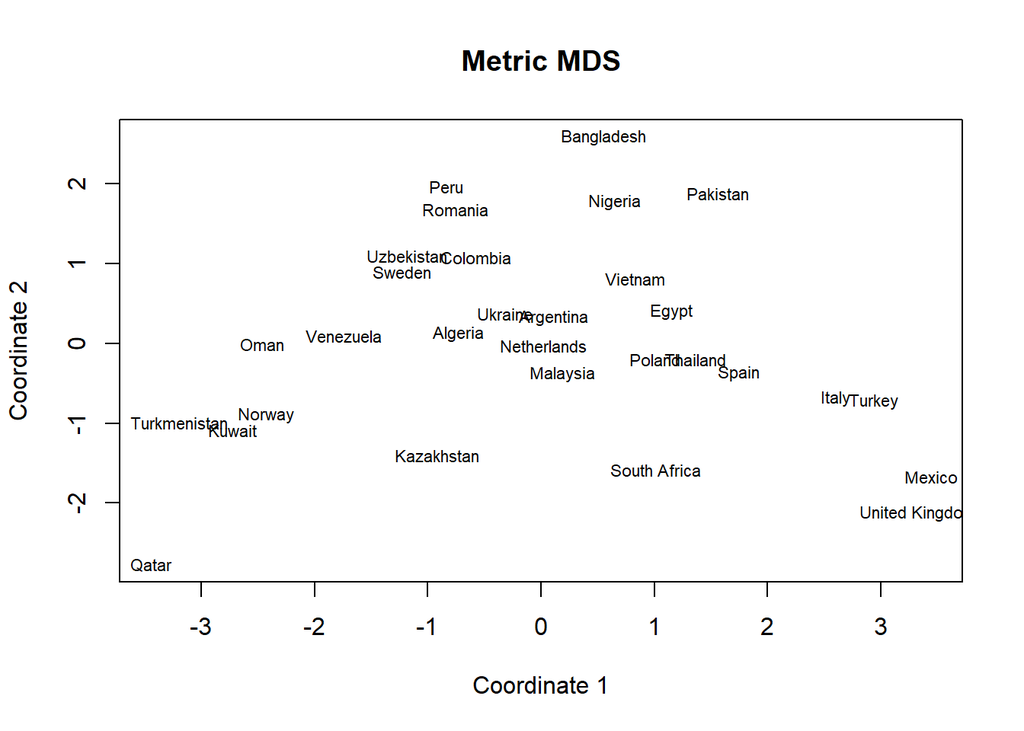

```r
# plot solution
x <- fit$points[,1]
y <- fit$points[,2]
plot(x, y, xlab="Coordinate 1", ylab="Coordinate 2",
  main="Metric MDS", type="n")
text(x, y, labels = row.names(energy), cex=.7)
```

Bibliografia:

[1] https://cran.r-project.org/web/packages/clusterSim/clusterSim.pdf